# lol

[figure not shown]

**WHAT IS LEAGUE OF LEGENDS?**

League of Legends is a team-based strategy game where two teams of five powerful champions face off to destroy the other’s base. Choose from over 150 champions to make epic plays, secure kills, and take down towers as you battle your way to victory.

**DESTROY THE BASE**

The Nexus is the heart of both teams’ bases. Destroy the enemy’s Nexus first to win the game.

**THE MAP**

[figure not shown]

Blue and Red team fight on the same map every game. Blue side is on the bottom-left corner, and Red side is on the upper-right corner. The map is symmetrical to its center. It is composed of 3 lanes (toplane, midlane, botlane) and jungle between them. Players pick position in accordance with the role they have decided in the champion select, and has to move from their respective Nexus to the correct position. Each time a player dies or decides to back, he spawns at his respective Nexus.

**CLEAR THE PATH**

Your team needs to clear at least one lane to get to the enemy Nexus. Blocking your path are defense structures called turrets and inhibitors. Each lane has three turrets and one inhibitor, and each Nexus is guarded by two turrets.

**TAKE ON THE JUNGLE**

In between the lanes is the jungle, where neutral monsters and jungle plants reside. The two most important monsters are Baron Nashor, the Heralds and the Drakes. Killing these units grants unique buffs for your team and can also turn the tide of the game.

**CHOOSE THE LANE**

There are five positions that make up the recommended team comp for the game. Each lane lends itself to certain kinds of champions and roles—try them all or lock in to the lane that calls you.

**POWER THE CHAMP**

Champions get stronger by earning experience to level up and gold to buy more powerful items as the game progresses. Staying on top of these two factors is crucial to overpowering the enemy team and destroying their base.

**UNLOCK ABILITIES**

Champions have five core abilities, two special spells, and up to seven items at a time. Figuring out the optimal ability order, summoner spells, and item build for your champion will help you succeed as a team.

**DATASET**

This dataset contains the first 10min. stats of approx. 10k ranked games (SOLO QUEUE) from a high ELO (DIAMOND I to MASTER). Players have roughly the same level.

Each game is unique. The gameId can help you to fetch more attributes from the Riot API.

There are 19 features per team (38 in total) collected after 10min in-game. This includes kills, deaths, gold, experience, level…

The column blueWins is the target value. A value of 1 means the blue team has won. 0 otherwise.

There is no missing value.

In this notebook, we will try to:

- determine which features are relevant to win the game and which are not
- predict the winning percentage of the game based on the first 10 minutes of the game

```python
import pandas as pd
pd.set_option('display.max_columns', 500)

from scipy.stats import ttest_1samp

from matplotlib import pyplot as plt
import seaborn as sns

from sklearn.model_selection import train_test_split
from sklearn.linear_model import LogisticRegression
from sklearn.ensemble import RandomForestClassifier, GradientBoostingClassifier, AdaBoostClassifier, ExtraTreesClassifier
from sklearn.tree import DecisionTreeClassifier
from sklearn.svm import SVC
from xgboost import XGBClassifier
from lightgbm import LGBMClassifier
from catboost import CatBoostClassifier
from sklearn.metrics import accuracy_score, confusion_matrix, classification_report

import time
import warnings
warnings.filterwarnings('ignore')
```

# Prepare data

```python
df = pd.read_csv('high_diamond_ranked_10min.csv')
df.head()
```

|  | gameId | blueWins | blueWardsPlaced | blueWardsDestroyed | blueFirstBlood | blueKills | blueDeaths | blueAssists | blueEliteMonsters | blueDragons | blueHeralds | blueTowersDestroyed | blueTotalGold | blueAvgLevel | blueTotalExperience | blueTotalMinionsKilled | blueTotalJungleMinionsKilled | blueGoldDiff | blueExperienceDiff | blueCSPerMin | blueGoldPerMin | redWardsPlaced | redWardsDestroyed | redFirstBlood | redKills | redDeaths | redAssists | redEliteMonsters | redDragons | … |
| --- | --- | --- | --- | --- | --- | --- | --- | --- | --- | --- | --- | --- | --- | --- | --- | --- | --- | --- | --- | --- | --- | --- | --- | --- | --- | --- | --- | --- | --- | --- |
| 0 | 4519157822 | 0 | 28 | 2 | 1 | 9 | 6 | 11 | 0 | 0 | 0 | 0 | 17210 | 6.6 | 17039 | 195 | 36 | 643 | -8 | 19.5 | 1721.0 | 15 | 6 | 0 | 6 | 9 | 8 | 0 | 0 | … |
| 1 | 4523371949 | 0 | 12 | 1 | 0 | 5 | 5 | 5 | 0 | 0 | 0 | 0 | 14712 | 6.6 | 16265 | 174 | 43 | -2908 | -1173 | 17.4 | 1471.2 | 12 | 1 | 1 | 5 | 5 | 2 | 2 | 1 | … |
| 2 | 4521474530 | 0 | 15 | 0 | 0 | 7 | 11 | 4 | 1 | 1 | 0 | 0 | 16113 | 6.4 | 16221 | 186 | 46 | -1172 | -1033 | 18.6 | 1611.3 | 15 | 3 | 1 | 11 | 7 | 14 | 0 | 0 | … |
| 3 | 4524384067 | 0 | 43 | 1 | 0 | 4 | 5 | 5 | 1 | 0 | 1 | 0 | 15157 | 7.0 | 17954 | 201 | 55 | -1321 | -7 | 20.1 | 1515.7 | 15 | 2 | 1 | 5 | 4 | 10 | 0 | 0 | … |
| 4 | 4436033771 | 0 | 75 | 4 | 0 | 6 | 6 | 6 | 0 | 0 | 0 | 0 | 16400 | 7.0 | 18543 | 210 | 57 | -1004 | 230 | 21.0 | 1640.0 | 17 | 2 | 1 | 6 | 6 | 7 | 1 | 1 | … |

```python
df.info()
```

```
<class 'pandas.core.frame.DataFrame'>
RangeIndex: 9879 entries, 0 to 9878
Data columns (total 40 columns):
 #   Column                        Non-Null Count  Dtype
---  ------                        --------------  -----
 0   gameId                        9879 non-null   int64
 1   blueWins                      9879 non-null   int64
 2   blueWardsPlaced               9879 non-null   int64
 3   blueWardsDestroyed            9879 non-null   int64
 4   blueFirstBlood                9879 non-null   int64
 5   blueKills                     9879 non-null   int64
 6   blueDeaths                    9879 non-null   int64
 7   blueAssists                   9879 non-null   int64
 8   blueEliteMonsters             9879 non-null   int64
 9   blueDragons                   9879 non-null   int64
```

[output cut: 32 more lines]

**Note**: All columns are numeric, so we can use .describe() to get a quick overview of the data

```python
df.describe()
```

|  | gameId | blueWins | blueWardsPlaced | blueWardsDestroyed | blueFirstBlood | blueKills | blueDeaths | blueAssists | blueEliteMonsters | blueDragons | blueHeralds | blueTowersDestroyed | blueTotalGold | blueAvgLevel | blueTotalExperience | blueTotalMinionsKilled | blueTotalJungleMinionsKilled | blueGoldDiff | blueExperienceDiff | blueCSPerMin | blueGoldPerMin | redWardsPlaced | redWardsDestroyed | redFirstBlood | redKills | redDeaths | redAssists | redEliteMonsters | redDragons | … |
| --- | --- | --- | --- | --- | --- | --- | --- | --- | --- | --- | --- | --- | --- | --- | --- | --- | --- | --- | --- | --- | --- | --- | --- | --- | --- | --- | --- | --- | --- | --- |
| count | 9.879000e+03 | 9879.000000 | 9879.000000 | 9879.000000 | 9879.000000 | 9879.000000 | 9879.000000 | 9879.000000 | 9879.000000 | 9879.000000 | 9879.000000 | 9879.000000 | 9879.000000 | 9879.000000 | 9879.000000 | 9879.000000 | 9879.000000 | 9879.000000 | 9879.000000 | 9879.000000 | 9879.000000 | 9879.000000 | 9879.000000 | 9879.000000 | 9879.000000 | 9879.000000 | 9879.000000 | 9879.000000 | 9879.000000 | … |
| mean | 4.500084e+09 | 0.499038 | 22.288288 | 2.824881 | 0.504808 | 6.183925 | 6.137666 | 6.645106 | 0.549954 | 0.361980 | 0.187974 | 0.051422 | 16503.455512 | 6.916004 | 17928.110133 | 216.699565 | 50.509667 | 14.414111 | -33.620306 | 21.669956 | 1650.345551 | 22.367952 | 2.723150 | 0.495192 | 6.137666 | 6.183925 | 6.662112 | 0.573135 | 0.413098 | … |
| std | 2.757328e+07 | 0.500024 | 18.019177 | 2.174998 | 0.500002 | 3.011028 | 2.933818 | 4.064520 | 0.625527 | 0.480597 | 0.390712 | 0.244369 | 1535.446636 | 0.305146 | 1200.523764 | 21.858437 | 9.898282 | 2453.349179 | 1920.370438 | 2.185844 | 153.544664 | 18.457427 | 2.138356 | 0.500002 | 2.933818 | 3.011028 | 4.060612 | 0.626482 | 0.492415 | … |
| min | 4.295358e+09 | 0.000000 | 5.000000 | 0.000000 | 0.000000 | 0.000000 | 0.000000 | 0.000000 | 0.000000 | 0.000000 | 0.000000 | 0.000000 | 10730.000000 | 4.600000 | 10098.000000 | 90.000000 | 0.000000 | -10830.000000 | -9333.000000 | 9.000000 | 1073.000000 | 6.000000 | 0.000000 | 0.000000 | 0.000000 | 0.000000 | 0.000000 | 0.000000 | 0.000000 | … |
| 25% | 4.483301e+09 | 0.000000 | 14.000000 | 1.000000 | 0.000000 | 4.000000 | 4.000000 | 4.000000 | 0.000000 | 0.000000 | 0.000000 | 0.000000 | 15415.500000 | 6.800000 | 17168.000000 | 202.000000 | 44.000000 | -1585.500000 | -1290.500000 | 20.200000 | 1541.550000 | 14.000000 | 1.000000 | 0.000000 | 4.000000 | 4.000000 | 4.000000 | 0.000000 | 0.000000 | … |
| 50% | 4.510920e+09 | 0.000000 | 16.000000 | 3.000000 | 1.000000 | 6.000000 | 6.000000 | 6.000000 | 0.000000 | 0.000000 | 0.000000 | 0.000000 | 16398.000000 | 7.000000 | 17951.000000 | 218.000000 | 50.000000 | 14.000000 | -28.000000 | 21.800000 | 1639.800000 | 16.000000 | 2.000000 | 0.000000 | 6.000000 | 6.000000 | 6.000000 | 0.000000 | 0.000000 | … |
| 75% | 4.521733e+09 | 1.000000 | 20.000000 | 4.000000 | 1.000000 | 8.000000 | 8.000000 | 9.000000 | 1.000000 | 1.000000 | 0.000000 | 0.000000 | 17459.000000 | 7.200000 | 18724.000000 | 232.000000 | 56.000000 | 1596.000000 | 1212.000000 | 23.200000 | 1745.900000 | 20.000000 | 4.000000 | 1.000000 | 8.000000 | 8.000000 | 9.000000 | 1.000000 | 1.000000 | … |
| max | 4.527991e+09 | 1.000000 | 250.000000 | 27.000000 | 1.000000 | 22.000000 | 22.000000 | 29.000000 | 2.000000 | 1.000000 | 1.000000 | 4.000000 | 23701.000000 | 8.000000 | 22224.000000 | 283.000000 | 92.000000 | 11467.000000 | 8348.000000 | 28.300000 | 2370.100000 | 276.000000 | 24.000000 | 1.000000 | 22.000000 | 22.000000 | 28.000000 | 2.000000 | 1.000000 | … |

```python
print('NaN values: ', df.isna().sum().sum())
```

```
NaN values:  0
```

**Note**: Data don't have any missing values

```python
df.drop_duplicates(inplace=True)
```

# Clean data

```python
df['gameId'].nunique() == len(df)
```

```
True
```

**Note**: There are no duplicate games, so the gameId is valid. We can drop it.

```python
df.drop('gameId', axis=1, inplace=True)
```

As domain knowledge, we know that the game first blood is just for only one team. So *blueFirstBlood* is the opposite of *redFirstBlood*. We must check if there are any inconsistencies.

```python
sum(df['blueFirstBlood'] == df['redFirstBlood'])  # validate that there are no games where both teams got first blood
```

```
0
```

*blueGoldDiff* and *redGoldDiff* are must be the opposite of each other. We must check if there are any inconsistencies.

```python
sum(df['blueGoldDiff'] != -df['redGoldDiff'])  # validate that there are no games where the gold difference is not the same for both teams
```

```
0
```

*blueExperienceDiff* and *redExperienceDiff* are must be the opposite of each other. We must check if there are any inconsistencies.

```python
sum(df['blueExperienceDiff'] != -df['redExperienceDiff'])  # validate that there are no games where the experience difference is not the same for both teams
```

```
0
```

# Hyporthesis test: Is there a significant win rate difference between the blue team and the red team?

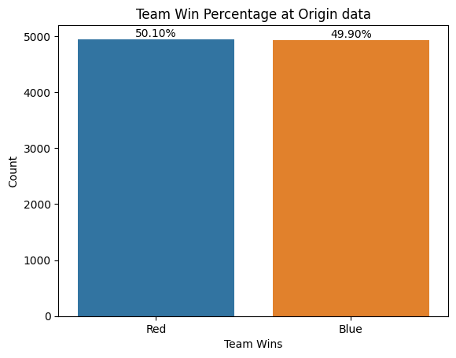

```python
sns.countplot(x='blueWins', data=df)
plt.xlabel('Team Wins')
plt.ylabel('Count')
plt.xticks([0, 1], ['Red', 'Blue'])
for p in plt.gca().patches:
  height = p.get_height()
  percentage = f'{100 * height / len(df):.2f}%'
  plt.gca().annotate(percentage, (p.get_x() + p.get_width() / 2, height), ha='center', va='bottom')
plt.title('Team Win Percentage at Origin data')
plt.show()
```

**H0**: Porportion of blue team win rate = Porportion of red team win rate = 0.5  
**H1**: Porportion of blue team win rate != Porportion of red team win rate != 0.5

We will use One-sample proportion tests

```python
mu = 0.5
alpha = 0.05
_, p_value = ttest_1samp(df['blueWins'], mu, alternative='two-sided')
print('p-value: ', p_value)
```

```
p-value:  0.8484114428598137
```

```python
if p_value < alpha:
  print('Reject H0')
else:
  print('Fail to reject H0')
```

```
Fail to reject H0
```

**Note**: Because p_value is greater than 0.05, we fail to reject the null hypothesis. So there is no significant win rate difference between the blue team and the red team. In other words, the blue team and the red team have the same win rate 50%.

**Note 2**: So that we move red team data to new rows and change suffixes of columns from _blue and _red to _friendly and _enemy. The result is double rows of data that blue team and red team are treated equally.

# Manipulate data

```python
new_df = {}
for col in df.columns:
  if col.startswith('blue'):
    new_df['friendly' + col[len('blue'):]] = []
  elif col.startswith('red'):
    new_df['enemy' + col[len('red'):]] = []
```

```python
for index, row in df.iterrows():
  for team in ['blue', 'red']:
    if team == 'red':
      new_df['friendlyWins'].append(1 - row['blueWins'])
      for col in df.columns[1:]:
        if col.startswith('red'):
          new_df['friendly' + col[len('red'):]].append(row[col])
        else:
          new_df['enemy' + col[len('blue'):]].append(row[col])
    else:
      new_df['friendlyWins'].append(row['blueWins'])
      for col in df.columns[1:]:
        if col.startswith('blue'):
          new_df['friendly' + col[len('blue'):]].append(row[col])
        else:
          new_df['enemy' + col[len('red'):]].append(row[col])
```

```python
new_df = pd.DataFrame(new_df)
new_df.head()
```

|  | friendlyWins | friendlyWardsPlaced | friendlyWardsDestroyed | friendlyFirstBlood | friendlyKills | friendlyDeaths | friendlyAssists | friendlyEliteMonsters | friendlyDragons | friendlyHeralds | friendlyTowersDestroyed | friendlyTotalGold | friendlyAvgLevel | friendlyTotalExperience | friendlyTotalMinionsKilled | friendlyTotalJungleMinionsKilled | friendlyGoldDiff | friendlyExperienceDiff | friendlyCSPerMin | friendlyGoldPerMin | enemyWardsPlaced | enemyWardsDestroyed | enemyFirstBlood | enemyKills | enemyDeaths | enemyAssists | enemyEliteMonsters | enemyDragons | enemyHeralds | … |
| --- | --- | --- | --- | --- | --- | --- | --- | --- | --- | --- | --- | --- | --- | --- | --- | --- | --- | --- | --- | --- | --- | --- | --- | --- | --- | --- | --- | --- | --- | --- |
| 0 | 0.0 | 28.0 | 2.0 | 1.0 | 9.0 | 6.0 | 11.0 | 0.0 | 0.0 | 0.0 | 0.0 | 17210.0 | 6.6 | 17039.0 | 195.0 | 36.0 | 643.0 | -8.0 | 19.5 | 1721.0 | 15.0 | 6.0 | 0.0 | 6.0 | 9.0 | 8.0 | 0.0 | 0.0 | 0.0 | … |
| 1 | 1.0 | 15.0 | 6.0 | 0.0 | 6.0 | 9.0 | 8.0 | 0.0 | 0.0 | 0.0 | 0.0 | 16567.0 | 6.8 | 17047.0 | 197.0 | 55.0 | -643.0 | 8.0 | 19.7 | 1656.7 | 28.0 | 2.0 | 1.0 | 9.0 | 6.0 | 11.0 | 0.0 | 0.0 | 0.0 | … |
| 2 | 0.0 | 12.0 | 1.0 | 0.0 | 5.0 | 5.0 | 5.0 | 0.0 | 0.0 | 0.0 | 0.0 | 14712.0 | 6.6 | 16265.0 | 174.0 | 43.0 | -2908.0 | -1173.0 | 17.4 | 1471.2 | 12.0 | 1.0 | 1.0 | 5.0 | 5.0 | 2.0 | 2.0 | 1.0 | 1.0 | … |
| 3 | 1.0 | 12.0 | 1.0 | 1.0 | 5.0 | 5.0 | 2.0 | 2.0 | 1.0 | 1.0 | 1.0 | 17620.0 | 6.8 | 17438.0 | 240.0 | 52.0 | 2908.0 | 1173.0 | 24.0 | 1762.0 | 12.0 | 1.0 | 0.0 | 5.0 | 5.0 | 5.0 | 0.0 | 0.0 | 0.0 | … |
| 4 | 0.0 | 15.0 | 0.0 | 0.0 | 7.0 | 11.0 | 4.0 | 1.0 | 1.0 | 0.0 | 0.0 | 16113.0 | 6.4 | 16221.0 | 186.0 | 46.0 | -1172.0 | -1033.0 | 18.6 | 1611.3 | 15.0 | 3.0 | 1.0 | 11.0 | 7.0 | 14.0 | 0.0 | 0.0 | 0.0 | … |

Create KDA features

```python
friendly_kda = []
enemy_kda = []
for index, row in new_df.iterrows():
  if row['friendlyDeaths'] == 0:
    friendly_kda.append(row['friendlyKills'] + row['friendlyAssists'])
  else:
    friendly_kda.append((row['friendlyKills'] + row['friendlyAssists']) / row['friendlyDeaths'])

  if row['enemyDeaths'] == 0:
    enemy_kda.append(row['enemyKills'] + row['enemyAssists'])
  else:
    enemy_kda.append((row['enemyKills'] + row['enemyAssists']) / row['enemyDeaths'])

new_df['friendlyKDA'] = friendly_kda
new_df['enemyKDA'] = enemy_kda
```

Create difference features between friendly and enemy columns

```python
new_df['diffWardsPlaced'] = new_df['friendlyWardsPlaced'] - new_df['enemyWardsPlaced']
new_df['diffWardsDestroyed'] = new_df['friendlyWardsDestroyed'] - new_df['enemyWardsDestroyed']
new_df['firstBlood'] = new_df['friendlyFirstBlood']
new_df['diffKills'] = new_df['friendlyKills'] - new_df['enemyKills']
new_df['diffDeaths'] = new_df['friendlyDeaths'] - new_df['enemyDeaths']
new_df['diffAssists'] = new_df['friendlyAssists'] - new_df['enemyAssists']
new_df['diffEliteMonsters'] = new_df['friendlyEliteMonsters'] - new_df['enemyEliteMonsters']
new_df['diffDragons'] = new_df['friendlyDragons'] - new_df['enemyDragons']
new_df['diffHeralds'] = new_df['friendlyHeralds'] - new_df['enemyHeralds']
new_df['diffTowersDestroyed'] = new_df['friendlyTowersDestroyed'] - new_df['enemyTowersDestroyed']
new_df['diffGold'] = new_df['friendlyGoldDiff']
new_df['diffAvgLevel'] = new_df['friendlyAvgLevel'] - new_df['enemyAvgLevel']
new_df['diffExperience'] = new_df['friendlyExperienceDiff']
new_df['diffMinionsKilled'] = new_df['friendlyTotalMinionsKilled'] - new_df['enemyTotalMinionsKilled']
new_df['diffJungleMinionsKilled'] = new_df['friendlyTotalJungleMinionsKilled'] - new_df['enemyTotalJungleMinionsKilled']
new_df['diffCSPerMin'] = new_df['friendlyCSPerMin'] - new_df['enemyCSPerMin']
new_df['diffGoldPerMin'] = new_df['friendlyGoldPerMin'] - new_df['enemyGoldPerMin']
new_df['diffKDA'] = new_df['friendlyKDA'] - new_df['enemyKDA']
```

Drop unnecessary columns

```python
new_df.drop([
  'friendlyFirstBlood', 'friendlyKills', 'friendlyDeaths', 'friendlyAssists', 'friendlyEliteMonsters',
  'friendlyDragons', 'friendlyHeralds', 'friendlyTowersDestroyed', 'friendlyGoldDiff', 'friendlyAvgLevel',
  'friendlyExperienceDiff', 'friendlyTotalMinionsKilled', 'friendlyTotalJungleMinionsKilled', 'friendlyCSPerMin',
  'friendlyGoldPerMin', 'enemyFirstBlood', 'enemyKills', 'enemyDeaths', 'enemyAssists', 'enemyEliteMonsters',
  'enemyDragons', 'enemyHeralds', 'enemyTowersDestroyed', 'enemyGoldDiff', 'enemyAvgLevel', 'enemyExperienceDiff',
  'enemyTotalMinionsKilled', 'enemyTotalJungleMinionsKilled', 'enemyCSPerMin', 'enemyGoldPerMin', 'friendlyWardsPlaced',
  'enemyWardsPlaced', 'friendlyWardsDestroyed', 'enemyWardsDestroyed', 'friendlyTotalGold', 'friendlyTotalExperience',
  'enemyTotalGold', 'enemyTotalExperience', 'enemyTotalGold', 'enemyTotalExperience', 'friendlyKDA', 'enemyKDA'
], axis=1, inplace=True)
```

# Train, test split

**Before go further, we must split the data into train and test sets to avoid data leakage.**

```python
df_train, df_test = train_test_split(new_df, test_size=0.2, random_state=42, stratify=new_df['friendlyWins'])
```

```python
df_train.describe()
```

|  | friendlyWins | diffWardsPlaced | diffWardsDestroyed | firstBlood | diffKills | diffDeaths | diffAssists | diffEliteMonsters | diffDragons | diffHeralds | diffTowersDestroyed | diffGold | diffAvgLevel | diffExperience | diffMinionsKilled | diffJungleMinionsKilled | diffCSPerMin | diffGoldPerMin | diffKDA |
| --- | --- | --- | --- | --- | --- | --- | --- | --- | --- | --- | --- | --- | --- | --- | --- | --- | --- | --- | --- |
| count | 15806.000000 | 15806.000000 | 15806.000000 | 15806.000000 | 15806.00000 | 15806.00000 | 15806.000000 | 15806.000000 | 15806.000000 | 15806.000000 | 15806.000000 | 15806.000000 | 15806.000000 | 15806.000000 | 15806.000000 | 15806.000000 | 15806.000000 | 15806.000000 | 15806.000000 |
| mean | 0.500000 | 0.104454 | 0.005441 | 0.500949 | -0.00601 | 0.00601 | -0.000759 | -0.000822 | -0.003480 | 0.002657 | -0.000063 | -4.932621 | -0.002683 | -8.644376 | -0.061116 | -0.037770 | -0.006112 | -0.493262 | -0.014567 |
| std | 0.500016 | 26.038485 | 2.845906 | 0.500015 | 4.16984 | 4.16984 | 5.748455 | 1.068516 | 0.880698 | 0.589473 | 0.321437 | 2441.729603 | 0.476593 | 1915.058145 | 31.039593 | 14.314846 | 3.103959 | 244.172960 | 5.131358 |
| min | 0.000000 | -254.000000 | -22.000000 | 0.000000 | -16.00000 | -17.00000 | -22.000000 | -2.000000 | -1.000000 | -1.000000 | -3.000000 | -10830.000000 | -2.600000 | -9333.000000 | -127.000000 | -72.000000 | -12.700000 | -1083.000000 | -39.823529 |
| 25% | 0.000000 | -4.000000 | -1.000000 | 0.000000 | -3.00000 | -3.00000 | -4.000000 | -1.000000 | -1.000000 | 0.000000 | 0.000000 | -1573.750000 | -0.400000 | -1263.750000 | -20.000000 | -9.000000 | -2.000000 | -157.375000 | -2.168290 |
| 50% | 0.500000 | 0.000000 | 0.000000 | 1.000000 | 0.00000 | 0.00000 | 0.000000 | 0.000000 | 0.000000 | 0.000000 | 0.000000 | 3.500000 | 0.000000 | -5.500000 | 0.000000 | 0.000000 | 0.000000 | 0.350000 | 0.000000 |
| 75% | 1.000000 | 4.000000 | 1.000000 | 1.000000 | 3.00000 | 3.00000 | 4.000000 | 1.000000 | 1.000000 | 0.000000 | 0.000000 | 1577.000000 | 0.400000 | 1240.000000 | 20.000000 | 9.000000 | 2.000000 | 157.700000 | 2.166667 |
| max | 1.000000 | 260.000000 | 23.000000 | 1.000000 | 17.00000 | 16.00000 | 25.000000 | 2.000000 | 1.000000 | 1.000000 | 3.000000 | 10830.000000 | 2.600000 | 9333.000000 | 127.000000 | 72.000000 | 12.700000 | 1083.000000 | 35.833333 |

# EDA

## Correlation

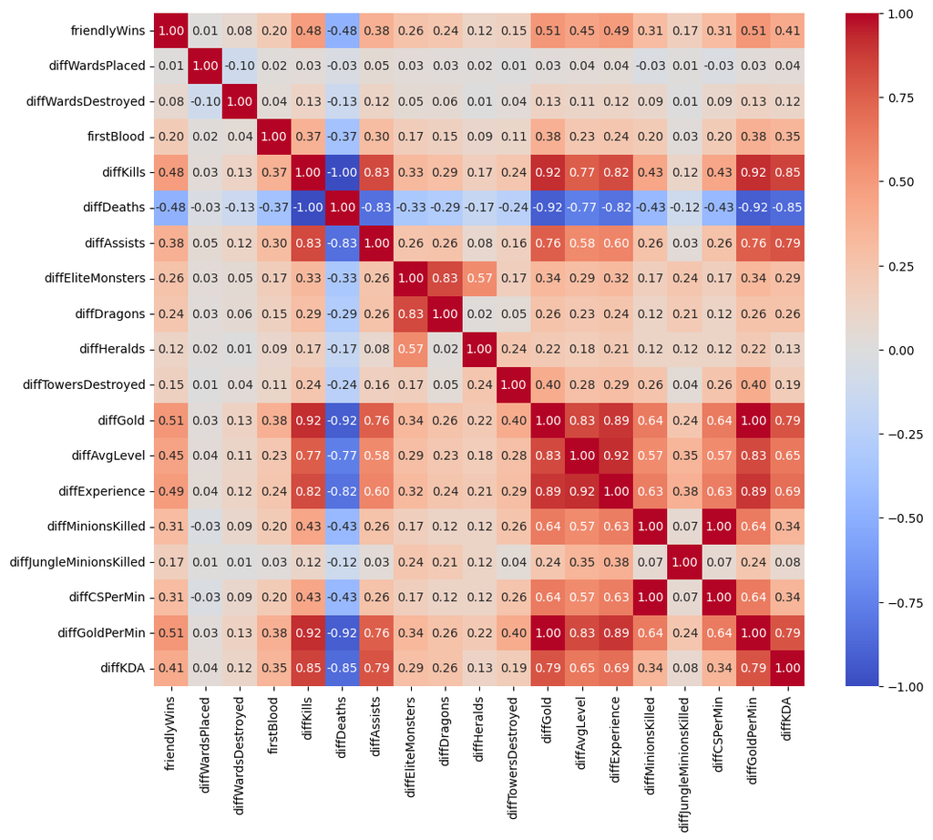

```python
plt.figure(figsize=(12, 10))
sns.heatmap(df_train.corr(), cmap='coolwarm', annot=True, fmt='.2f')
plt.show()
```

## Mean of stats by win/loss

```python
df_train.groupby('friendlyWins').mean()
```

| friendlyWins | diffWardsPlaced | diffWardsDestroyed | firstBlood | diffKills | diffDeaths | diffAssists | diffEliteMonsters | diffDragons | diffHeralds | diffTowersDestroyed | diffGold | diffAvgLevel | diffExperience | diffMinionsKilled | diffJungleMinionsKilled | diffCSPerMin | diffGoldPerMin | diffKDA |
| --- | --- | --- | --- | --- | --- | --- | --- | --- | --- | --- | --- | --- | --- | --- | --- | --- | --- | --- |
| 0.0 | -0.273187 | -0.215235 | 0.400987 | -1.995571 | 1.995571 | -2.178287 | -0.281665 | -0.212578 | -0.069088 | -0.049222 | -1245.481716 | -0.217715 | -941.380741 | -9.550677 | -2.436417 | -0.955068 | -124.548172 | -2.116901 |
| 1.0 | 0.482095 | 0.226117 | 0.600911 | 1.983551 | -1.983551 | 2.176768 | 0.280020 | 0.205618 | 0.074402 | 0.049095 | 1235.616475 | 0.212350 | 924.091990 | 9.428445 | 2.360876 | 0.942844 | 123.561647 | 2.087767 |

**Note**: In genaral, the team with the higher stats like wards placed, wards destroyed, KDA, gold, experience, Drake, Herald, towers destroyed, etc. will win the game.

## Wards placed

```python
df_train.groupby('diffWardsPlaced')['friendlyWins'].agg(['mean', 'count'])
```

| diffWardsPlaced | mean | count |
| --- | --- | --- |
| -254.0 | 1.0 | 1 |
| -234.0 | 0.0 | 1 |
| -218.0 | 0.0 | 1 |
| -200.0 | 0.0 | 1 |
| -195.0 | 1.0 | 1 |
| ... | ... | ... |
| 200.0 | 1.0 | 1 |
| 218.0 | 1.0 | 1 |
| 234.0 | 1.0 | 1 |
| 254.0 | 0.0 | 1 |
| 260.0 | 1.0 | 1 |

316 rows × 2 columns

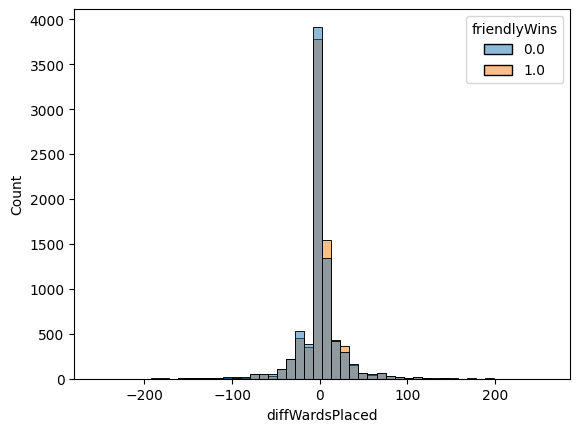

```python
sns.histplot(x='diffWardsPlaced', hue='friendlyWins', data=df_train, bins=50, kde=False)
plt.show()
```

## Elite monsters

```python
df_train.groupby('diffEliteMonsters')['friendlyWins'].agg(['mean', 'count'])
```

| diffEliteMonsters | mean | count |
| --- | --- | --- |
| -2.0 | 0.269398 | 1147 |
| -1.0 | 0.368231 | 4432 |
| 0.0 | 0.500000 | 4670 |
| 1.0 | 0.634174 | 4401 |
| 2.0 | 0.723183 | 1156 |

## First blood

```python
df_train.groupby('firstBlood')['friendlyWins'].mean()
```

```
firstBlood
0.0    0.399848
1.0    0.599773
Name: friendlyWins, dtype: float64
```

- Team got first blood has **60.00%** chance to win the game.

## KDA

```python
df_train.groupby('friendlyWins')['diffKDA'].mean()
```

```
friendlyWins
0.0   -2.116901
1.0    2.087767
Name: diffKDA, dtype: float64
```

```python
min_diffKDA = int(df_train['diffKDA'].min())
max_diffKDA = int(df_train['diffKDA'].max())
step = 10

for i in range(min_diffKDA, max_diffKDA, step):
  winning_rate = df_train[(df_train['diffKDA'] >= i) & (df_train['diffKDA'] < i + step)]['friendlyWins'].mean()
  print(f'with diffKDA between {i} and {i + step}: winning rate is {winning_rate*100:.2f} %')
```

```
with diffKDA between -39 and -29: winning rate is 0.00 %
with diffKDA between -29 and -19: winning rate is 1.30 %
with diffKDA between -19 and -9: winning rate is 10.49 %
with diffKDA between -9 and 1: winning rate is 36.81 %
with diffKDA between 1 and 11: winning rate is 73.44 %
with diffKDA between 11 and 21: winning rate is 92.21 %
with diffKDA between 21 and 31: winning rate is 98.18 %
with diffKDA between 31 and 41: winning rate is 100.00 %
```

## diff Towers Destroyed

```python
gb_diffTowersDestroyed = df_train.groupby('diffTowersDestroyed')['friendlyWins'].mean()
```

```python
for idx in gb_diffTowersDestroyed.index:
  print(f'with diffTowersDestroyed = {idx}: winning rate is {gb_diffTowersDestroyed[idx]*100:.2f} %')
```

```
with diffTowersDestroyed = -3.0: winning rate is 0.00 %
with diffTowersDestroyed = -2.0: winning rate is 12.20 %
with diffTowersDestroyed = -1.0: winning rate is 25.25 %
with diffTowersDestroyed = 0.0: winning rate is 49.92 %
with diffTowersDestroyed = 1.0: winning rate is 76.66 %
with diffTowersDestroyed = 2.0: winning rate is 87.50 %
with diffTowersDestroyed = 3.0: winning rate is 100.00 %
```

```python
df_train.groupby(['friendlyWins', 'firstBlood'])['diffTowersDestroyed'].mean()
```

```
friendlyWins  firstBlood
0.0           0.0          -0.069497
              1.0          -0.018933
1.0           0.0           0.016487
              1.0           0.070752
Name: diffTowersDestroyed, dtype: float64
```

- At lose, the team got first blood can reduce the difference towers destroyed from -0.069 to -0.019
- At win, the team didn't get first blood can loss the difference towers destroyed from 0.071 to 0.016

## diff Gold

```python
min_diffGold = int(df_train['diffGold'].min())
max_diffGold = int(df_train['diffGold'].max())
step = 2000

for i in range(min_diffGold, max_diffGold, step):
  winning_rate = df_train[(df_train['diffGold'] >= i) & (df_train['diffGold'] < i + step)]['friendlyWins'].mean()
  print(f'with diffGold between {i} and {i + step}: winning rate is {winning_rate*100:.2f} %')
```

```
with diffGold between -10830 and -8830: winning rate is 0.00 %
with diffGold between -8830 and -6830: winning rate is 0.00 %
with diffGold between -6830 and -4830: winning rate is 3.43 %
with diffGold between -4830 and -2830: winning rate is 12.37 %
with diffGold between -2830 and -830: winning rate is 26.96 %
with diffGold between -830 and 1170: winning rate is 52.54 %
with diffGold between 1170 and 3170: winning rate is 76.11 %
with diffGold between 3170 and 5170: winning rate is 90.34 %
with diffGold between 5170 and 7170: winning rate is 98.43 %
with diffGold between 7170 and 9170: winning rate is 100.00 %
with diffGold between 9170 and 11170: winning rate is 100.00 %
```

## diff experience

```python
min_diffEXP = int(df_train['diffExperience'].min())
max_diffEXP = int(df_train['diffExperience'].max())
step = 2000

for i in range(min_diffEXP, max_diffEXP, step):
  winning_rate = df_train[(df_train['diffExperience'] >= i) & (df_train['diffExperience'] < i + step)]['friendlyWins'].mean()
  print(f'with diffExperience between {i} and {i + step}: winning rate is {winning_rate*100:.2f} %')
```

```
with diffExperience between -9333 and -7333: winning rate is 0.00 %
with diffExperience between -7333 and -5333: winning rate is 1.79 %
with diffExperience between -5333 and -3333: winning rate is 6.75 %
with diffExperience between -3333 and -1333: winning rate is 19.60 %
with diffExperience between -1333 and 667: winning rate is 44.98 %
with diffExperience between 667 and 2667: winning rate is 73.21 %
with diffExperience between 2667 and 4667: winning rate is 90.85 %
with diffExperience between 4667 and 6667: winning rate is 97.22 %
with diffExperience between 6667 and 8667: winning rate is 100.00 %
with diffExperience between 8667 and 10667: winning rate is 100.00 %
```

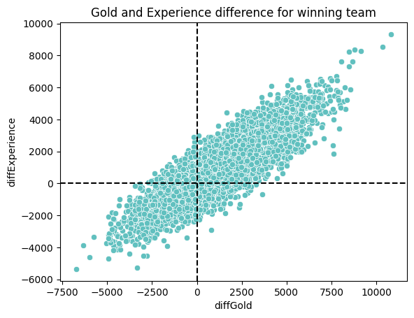

```python
sns.scatterplot(data=df_train[df_train['friendlyWins'] == 1], x='diffGold', y='diffExperience', color='#61C0BF')
plt.axvline(x=0, color='black', linestyle='--')
plt.axhline(y=0, color='black', linestyle='--')
plt.title('Gold and Experience difference for winning team')
plt.show()
```

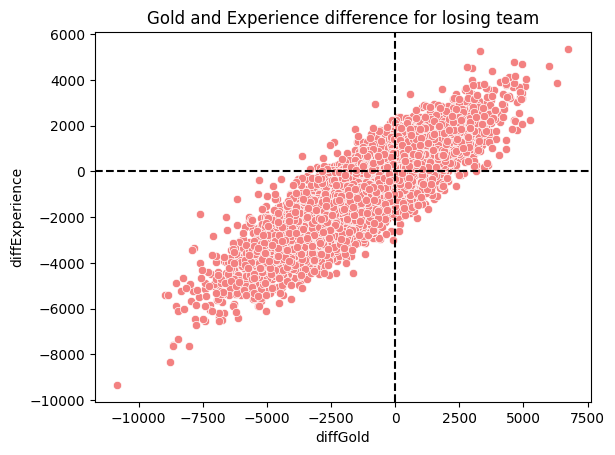

```python
sns.scatterplot(data=df_train[df_train['friendlyWins'] == 0], x='diffGold', y='diffExperience', color='#F38181')
plt.axvline(x=0, color='black', linestyle='--')
plt.axhline(y=0, color='black', linestyle='--')
plt.title('Gold and Experience difference for losing team')
plt.show()
```

# Predict model

```python
X = df_train.copy()
X.drop(
  [
    'diffWardsPlaced',	'diffWardsDestroyed', 'diffHeralds', 'diffTowersDestroyed', 'diffJungleMinionsKilled'
  ], axis=1, inplace=True)
y = X.pop('friendlyWins')

X_train, X_val, y_train, y_val = train_test_split(X, y, test_size=0.2, random_state=42, stratify=y)
```

```python
class LazyClassifier:
  def __init__(self, random_state=42):
    self.models = {
      'Logistic Regression': LogisticRegression(),
      'Random Forest': RandomForestClassifier(random_state=random_state),
      'Gradient Boosting': GradientBoostingClassifier(random_state=random_state),
      'AdaBoost': AdaBoostClassifier(random_state=random_state),
      'Extra Trees': ExtraTreesClassifier(random_state=random_state),
      'Decision Tree': DecisionTreeClassifier(random_state=random_state),
      'SVM': SVC(),
      'XGBoost': XGBClassifier(random_state=random_state),
      'LightGBM': LGBMClassifier(random_state=random_state),
      'CatBoost': CatBoostClassifier(verbose=False, random_seed=random_state)
    }
    self.fit_times = []
    self.predict_times = []
    self.train_scores = []
    self.val_scores = []

  def fit(self, X_train, y_train, X_val, y_val):
    for name, model in self.models.items():
      print(f'Fitting {name}...')
      t1_fitting = time.time()
      model.fit(X_train, y_train)
      t2_fitting = time.time()
      self.fit_times.append(t2_fitting - t1_fitting)
      train_score = accuracy_score(y_train, model.predict(X_train))
      self.train_scores.append(train_score)

      print(f'Predicting {name}...')
      t1_predicting = time.time()
      y_pred = model.predict(X_val)
      t2_predicting = time.time()
      self.predict_times.append(t2_predicting - t1_predicting)
      val_score = accuracy_score(y_val, y_pred)
      self.val_scores.append(val_score)
      print(f'{name} done after {t2_predicting - t1_fitting:.2f}s', end='\n\n')

  def summary(self):
    results = pd.DataFrame({
      'Model': list(self.models.keys()),
      'Train Score': self.train_scores,
      'Val Score': self.val_scores,
      'Fit Time': self.fit_times,
      'Predict Time': self.predict_times
    })
    return results.sort_values(['Val Score', 'Train Score'], ascending=False)
```

## Baseline model

```python
baseline_model = LazyClassifier()
baseline_model.fit(X_train, y_train, X_val, y_val)
```

```
Fitting Logistic Regression...
Predicting Logistic Regression...
Logistic Regression done after 0.09s

Fitting Random Forest...
Predicting Random Forest...
Random Forest done after 3.87s

Fitting Gradient Boosting...
Predicting Gradient Boosting...
Gradient Boosting done after 3.21s

Fitting AdaBoost...
Predicting AdaBoost...
AdaBoost done after 0.80s

Fitting Extra Trees...
Predicting Extra Trees...
Extra Trees done after 2.06s

Fitting Decision Tree...
Predicting Decision Tree...
Decision Tree done after 0.19s

Fitting SVM...
Predicting SVM...
SVM done after 14.76s

Fitting XGBoost...
Predicting XGBoost...
XGBoost done after 0.14s

Fitting LightGBM...
[LightGBM] [Info] Number of positive: 6322, number of negative: 6322
[LightGBM] [Info] Auto-choosing col-wise multi-threading, the overhead of testing was 0.000470 seconds.
You can set `force_col_wise=true` to remove the overhead.
[LightGBM] [Info] Total Bins 1621
[LightGBM] [Info] Number of data points in the train set: 12644, number of used features: 13
[LightGBM] [Info] [binary:BoostFromScore]: pavg=0.500000 -> initscore=0.000000
Predicting LightGBM...
LightGBM done after 0.17s

Fitting CatBoost...
Predicting CatBoost...
CatBoost done after 7.75s
```

```python
baseline_model.summary()
```

|  | Model | Train Score | Val Score | Fit Time | Predict Time |
| --- | --- | --- | --- | --- | --- |
| 3 | AdaBoost | 0.730228 | 0.744782 | 0.723273 | 0.019336 |
| 6 | SVM | 0.722082 | 0.741935 | 4.549563 | 2.104097 |
| 0 | Logistic Regression | 0.726906 | 0.741619 | 0.083477 | 0.001002 |
| 9 | CatBoost | 0.772619 | 0.741303 | 7.736666 | 0.003433 |
| 2 | Gradient Boosting | 0.739718 | 0.740354 | 3.188040 | 0.005680 |
| 8 | LightGBM | 0.778472 | 0.736243 | 0.154515 | 0.003527 |
| 1 | Random Forest | 0.999921 | 0.725490 | 3.632452 | 0.053254 |
| 4 | Extra Trees | 1.000000 | 0.722011 | 1.718927 | 0.077894 |
| 7 | XGBoost | 0.832094 | 0.717900 | 0.127292 | 0.004000 |
| 5 | Decision Tree | 1.000000 | 0.641999 | 0.178621 | 0.002045 |

## Standard scale

```python
from sklearn.preprocessing import StandardScaler
```

```python
scaler = StandardScaler()
X_train_scaled = scaler.fit_transform(X_train)
X_val_scaled = scaler.transform(X_val)
```

```python
scaled_model =  LazyClassifier()
scaled_model.fit(X_train_scaled, y_train, X_val_scaled, y_val)
```

```
Fitting Logistic Regression...
Predicting Logistic Regression...
Logistic Regression done after 0.03s

Fitting Random Forest...
Predicting Random Forest...
Random Forest done after 3.89s

Fitting Gradient Boosting...
Predicting Gradient Boosting...
Gradient Boosting done after 3.26s

Fitting AdaBoost...
Predicting AdaBoost...
AdaBoost done after 0.84s

Fitting Extra Trees...
Predicting Extra Trees...
Extra Trees done after 2.04s

Fitting Decision Tree...
Predicting Decision Tree...
Decision Tree done after 0.19s

Fitting SVM...
Predicting SVM...
SVM done after 15.32s

Fitting XGBoost...
Predicting XGBoost...
XGBoost done after 0.10s

Fitting LightGBM...
[LightGBM] [Info] Number of positive: 6322, number of negative: 6322
[LightGBM] [Info] Auto-choosing col-wise multi-threading, the overhead of testing was 0.000445 seconds.
You can set `force_col_wise=true` to remove the overhead.
[LightGBM] [Info] Total Bins 1629
[LightGBM] [Info] Number of data points in the train set: 12644, number of used features: 13
[LightGBM] [Info] [binary:BoostFromScore]: pavg=0.500000 -> initscore=0.000000
Predicting LightGBM...
LightGBM done after 0.10s

Fitting CatBoost...
Predicting CatBoost...
CatBoost done after 7.83s
```

```python
scaled_model.summary()
```

|  | Model | Train Score | Val Score | Fit Time | Predict Time |
| --- | --- | --- | --- | --- | --- |
| 0 | Logistic Regression | 0.729279 | 0.746363 | 0.027555 | 0.001007 |
| 3 | AdaBoost | 0.730228 | 0.744782 | 0.758977 | 0.018542 |
| 6 | SVM | 0.728725 | 0.743833 | 4.475697 | 2.198871 |
| 9 | CatBoost | 0.772619 | 0.741303 | 7.819383 | 0.007479 |
| 2 | Gradient Boosting | 0.739718 | 0.740354 | 3.242692 | 0.005013 |
| 8 | LightGBM | 0.776099 | 0.734029 | 0.084430 | 0.003232 |
| 1 | Random Forest | 0.999921 | 0.723909 | 3.653182 | 0.054327 |
| 4 | Extra Trees | 1.000000 | 0.722011 | 1.710580 | 0.076102 |
| 7 | XGBoost | 0.832094 | 0.717900 | 0.093278 | 0.003071 |
| 5 | Decision Tree | 1.000000 | 0.640734 | 0.181613 | 0.000997 |

## Polynomial features

```python
from sklearn.preprocessing import PolynomialFeatures
```

```python
poly = PolynomialFeatures(degree=2, include_bias=False)
```

```python
X_poly_train = poly.fit_transform(X_train)
X_poly_val = poly.transform(X_val)
```

```python
X_poly_train_scaled = scaler.fit_transform(X_poly_train)
X_poly_val_scaled = scaler.transform(X_poly_val)
```

```python
poly_model = LazyClassifier()
poly_model.fit(X_poly_train, y_train, X_poly_val, y_val)
```

```
Fitting Logistic Regression...
Predicting Logistic Regression...
Logistic Regression done after 0.28s

Fitting Random Forest...
Predicting Random Forest...
Random Forest done after 14.31s

Fitting Gradient Boosting...
Predicting Gradient Boosting...
Gradient Boosting done after 35.44s

Fitting AdaBoost...
Predicting AdaBoost...
AdaBoost done after 6.48s

Fitting Extra Trees...
Predicting Extra Trees...
Extra Trees done after 4.10s

Fitting Decision Tree...
Predicting Decision Tree...
Decision Tree done after 1.97s

Fitting SVM...
Predicting SVM...
SVM done after 48.73s

Fitting XGBoost...
Predicting XGBoost...
XGBoost done after 0.54s

Fitting LightGBM...
[LightGBM] [Info] Number of positive: 6322, number of negative: 6322
[LightGBM] [Info] Auto-choosing col-wise multi-threading, the overhead of testing was 0.004349 seconds.
You can set `force_col_wise=true` to remove the overhead.
[LightGBM] [Info] Total Bins 18436
[LightGBM] [Info] Number of data points in the train set: 12644, number of used features: 104
[LightGBM] [Info] [binary:BoostFromScore]: pavg=0.500000 -> initscore=0.000000
Predicting LightGBM...
LightGBM done after 0.34s

Fitting CatBoost...
Predicting CatBoost...
CatBoost done after 14.50s
```

```python
poly_model.summary()
```

|  | Model | Train Score | Val Score | Fit Time | Predict Time |
| --- | --- | --- | --- | --- | --- |
| 9 | CatBoost | 0.792075 | 0.743201 | 14.125572 | 0.078137 |
| 0 | Logistic Regression | 0.721686 | 0.743201 | 0.275979 | 0.001008 |
| 3 | AdaBoost | 0.728883 | 0.741935 | 6.192745 | 0.062771 |
| 2 | Gradient Boosting | 0.744622 | 0.736559 | 35.380134 | 0.006046 |
| 8 | LightGBM | 0.810978 | 0.728969 | 0.326339 | 0.004001 |
| 1 | Random Forest | 0.999921 | 0.725174 | 14.059252 | 0.057003 |
| 4 | Extra Trees | 1.000000 | 0.719481 | 3.799300 | 0.069373 |
| 7 | XGBoost | 0.901851 | 0.700506 | 0.527928 | 0.003000 |
| 5 | Decision Tree | 1.000000 | 0.641682 | 1.964353 | 0.002012 |
| 6 | SVM | 0.507039 | 0.488931 | 22.344151 | 5.245456 |

## Early stopping

```python
cat_model = CatBoostClassifier(loss_function='Logloss', task_type='GPU', random_state=42)
cat_model.fit(X_train, y_train, verbose=False, eval_set=[(X_val, y_val)], early_stopping_rounds=300)
y_pred = cat_model.predict(X_val)
print('Acurracy: ', accuracy_score(y_val, y_pred))
```

```
Acurracy:  0.7441492726122707
```

```python
print(classification_report(y_val, y_pred))
```

```
              precision    recall  f1-score   support

         0.0       0.75      0.73      0.74      1581
         1.0       0.74      0.76      0.75      1581

    accuracy                           0.74      3162
   macro avg       0.74      0.74      0.74      3162
weighted avg       0.74      0.74      0.74      3162
```

# Test model

```python
X_test = df_test.copy()
X_test.drop(
  [
    'diffWardsPlaced',	'diffWardsDestroyed', 'diffHeralds', 'diffTowersDestroyed', 'diffJungleMinionsKilled'
  ], axis=1, inplace=True)
y_test = X_test.pop('friendlyWins')
```

```python
y_pred = cat_model.predict(X_test)
print(accuracy_score(y_test, y_pred))
```

```
0.7386133603238867
```

```python
print(classification_report(y_test, y_pred))
```

```
              precision    recall  f1-score   support

         0.0       0.74      0.73      0.74      1976
         1.0       0.73      0.75      0.74      1976

    accuracy                           0.74      3952
   macro avg       0.74      0.74      0.74      3952
weighted avg       0.74      0.74      0.74      3952
```

```python
y_prob = cat_model.predict_proba(X_test)[:, 1]
y_prob = [round(prob*100, 2) for prob in y_prob]
```

```python
pd.DataFrame({
  'Actual': y_test,
  'Predicted': y_pred,
  'Winning chance (%)': y_prob
})
```

|  | Actual | Predicted | Winning chance (%) |
| --- | --- | --- | --- |
| 10969 | 1.0 | 1.0 | 65.80 |
| 8740 | 1.0 | 1.0 | 83.80 |
| 16778 | 1.0 | 0.0 | 21.26 |
| 889 | 1.0 | 1.0 | 73.70 |
| 4187 | 1.0 | 1.0 | 93.47 |
| ... | ... | ... | ... |
| 13962 | 0.0 | 0.0 | 17.74 |
| 9818 | 0.0 | 0.0 | 11.54 |
| 3047 | 0.0 | 0.0 | 25.71 |
| 18072 | 1.0 | 0.0 | 42.91 |
| 3030 | 1.0 | 1.0 | 98.09 |

3952 rows × 3 columns